| 주차 | 일정 | 페이지 |
| --- | --- | --- |
| 1 | 1장-헬로 파이썬 | 0p ~ 45p |
| 2 | 2장-퍼셉트론 | 46p ~ 62p |
| 3 | 3장-신경망 | 63p ~ 105p |
| 4 | 4장-신경망 학습 | 106p ~ 146p |
| 5 | 5장-오차역전파법 | 147p ~ 187p (+ Appendix A, 292p ~ 299p) |
| 6 | 중간고사(전) |  |
| 7 | 중간고사 |  |
| 8 | 6장-학습 관련 기술들 | 188p ~ 226p |
| 9 | 7장-합성곱 신경망(CNN) | 227p ~ 259p |
| 10 | 딥러닝 | 261p ~ 308p |
| 11 | 1장-신경망 복습 | 0p ~ 74p (+ Appendix A, 389p ~ 394p) |
| 12 | 2장-자연어와 단어의 분산 표현 | 78p ~ 113p (+ Appendix B, 395p ~ 399p) |
| 13 | 기말고사(전) |  |
| 14 | 기말고사 |  |
| 15 | 3장-word2vec | 114p ~ 147p |
| 16 | 4장-word2vec 속도 개선 | 148p ~ 189p |
| 17 | 5장-순환신경망(RNN) | 190p ~ 235p |
| 18 | 6장-게이트가 추가된 RNN | 263p ~ 286p (+ Appendix C, 401p ~ 402p) |
| 19 | 7장-RNN을 사용한 문장 생성 | 287p ~ 333p |
| 20 | 8장-어텐션 | 334p ~ 387p |

# 20차

*317p ~ 333p* (쪼갬)

### 7.3.4

앞서 한 seq2seq평가

```python
import sys
sys.path.append('..')
import numpy as np
import matplotlib.pyplot as plt

from dataset import sequence
from common.optimizer import Adam
from common.trainer import Trainer
from common.util import eval_seq2seq
from common.seq2seq import Seq2seq

# Load dataset
(x_train, t_train), (x_test, t_test) = sequence.load_data('addition.txt')
char_to_id, id_to_char = sequence.get_vocab()

# x_train = x_train[:, ::-1]
# x_test = x_test[:, ::-1]

# Hyperparameters
vocab_size   = len(char_to_id)
wordvec_size = 16
hidden_size  = 128
batch_size   = 128
max_epoch    = 25
max_grad     = 5.0

# Model, optimizer, trainer
model     = Seq2seq(vocab_size, wordvec_size, hidden_size)
optimizer = Adam()
trainer   = Trainer(model, optimizer)

# Training loop with validation
acc_list = []

for epoch in range(max_epoch):
    # Train for one epoch
    trainer.fit(
        x_train, t_train,
        max_epoch=1,
        batch_size=batch_size,
        max_grad=max_grad
    )

    # Evaluate on test set
    correct_num = 0
    for i in range(len(x_test)):
        question, correct = x_test[i], t_test[i]
        verbose = False # (i < 10)
        # Add batch dimension for single sample
        question = question.reshape(1, -1)
        correct = correct.reshape(1, -1)
        correct_num += eval_seq2seq(
            model, question, correct,
            id_to_char, verbose, is_reverse=False
        )

    acc = float(correct_num) / len(x_test)
    acc_list.append(acc)
    print('검증 정확도: %.3f%%' % (acc * 100), end=' | ')
    print(f'Epoch {epoch + 1}')
```

```
검증 정확도: 0.180% | Epoch 1
검증 정확도: 0.220% | Epoch 2
검증 정확도: 0.560% | Epoch 3
검증 정확도: 1.060% | Epoch 4
검증 정확도: 2.260% | Epoch 5
검증 정확도: 2.840% | Epoch 6
검증 정확도: 4.020% | Epoch 7
검증 정확도: 4.180% | Epoch 8
검증 정확도: 4.640% | Epoch 9
검증 정확도: 5.640% | Epoch 10
검증 정확도: 6.240% | Epoch 11
검증 정확도: 5.020% | Epoch 12
검증 정확도: 5.940% | Epoch 13
검증 정확도: 7.100% | Epoch 14
검증 정확도: 4.860% | Epoch 15
검증 정확도: 4.240% | Epoch 16
검증 정확도: 9.380% | Epoch 17
검증 정확도: 6.860% | Epoch 18
검증 정확도: 8.000% | Epoch 19
검증 정확도: 5.800% | Epoch 20
검증 정확도: 8.620% | Epoch 21
검증 정확도: 7.400% | Epoch 22
검증 정확도: 7.980% | Epoch 23
검증 정확도: 11.360% | Epoch 24
검증 정확도: 12.200% | Epoch 25
```

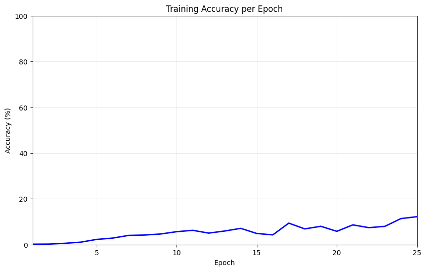

```
Final accuracy: 12.20%
```

```python
plt.figure(figsize=(10, 6))
plt.plot(range(1, len(acc_list) + 1), [acc * 100 for acc in acc_list], 'b-', linewidth=2)
plt.xlabel('Epoch')
plt.ylabel('Accuracy (%)')
plt.title('Training Accuracy per Epoch')
plt.grid(True, alpha=0.3)
plt.xlim(1, len(acc_list))
plt.ylim(0, 100)
plt.show()

print(f'Final accuracy: {acc_list[-1] * 100:.2f}%')
```

### 7.4

seq2seq 개선하기

가장 간단한 방법 중 하나로, 입력을 반전하는 것이다.

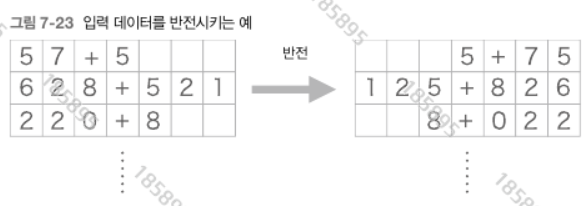

왜 잘되는지 잘 모르겠음... (양쪽 다 합해서 훈련하는 것도 아님) 일단은 오른쪽으로 몰아주면 전파가 잘된다고는 하니... 신기함

```python
(x_train_rev, t_train_rev), (x_test_rev, t_test_rev) = sequence.load_data('addition.txt')

x_train_rev = x_train_rev[:, ::-1]
x_test_rev = x_test_rev[:, ::-1]

model_reversed = Seq2seq(vocab_size, wordvec_size, hidden_size)
optimizer_reversed = Adam()
trainer_reversed = Trainer(model_reversed, optimizer_reversed)

acc_list_reversed = []

print("Training with REVERSED inputs...")
for epoch in range(max_epoch):
    trainer_reversed.fit(
        x_train_rev, t_train_rev,  # Note: using reversed x_train
        max_epoch=1,
        batch_size=batch_size,
        max_grad=max_grad
    )

    correct_num = 0
    for i in range(len(x_test_rev)):
        question, correct = x_test_rev[i], t_test_rev[i]
        verbose = False

        question = question.reshape(1, -1)
        correct = correct.reshape(1, -1)
        correct_num += eval_seq2seq(
            model_reversed, question, correct,
            id_to_char, verbose, is_reverse=True
        )

    acc = float(correct_num) / len(x_test_rev)
    acc_list_reversed.append(acc)
    print('검증 정확도: %.3f%%' % (acc * 100), end=' | ')
    print(f'Epoch {epoch + 1}')
```

```
Training with REVERSED inputs...
검증 정확도: 0.120% | Epoch 1
검증 정확도: 0.400% | Epoch 2
검증 정확도: 1.940% | Epoch 3
검증 정확도: 5.780% | Epoch 4
검증 정확도: 12.460% | Epoch 5
검증 정확도: 14.260% | Epoch 6
검증 정확도: 17.500% | Epoch 7
검증 정확도: 23.080% | Epoch 8
검증 정확도: 26.540% | Epoch 9
검증 정확도: 29.820% | Epoch 10
검증 정확도: 28.500% | Epoch 11
검증 정확도: 36.640% | Epoch 12
검증 정확도: 39.420% | Epoch 13
검증 정확도: 36.640% | Epoch 14
검증 정확도: 41.100% | Epoch 15
검증 정확도: 42.700% | Epoch 16
검증 정확도: 42.860% | Epoch 17
검증 정확도: 40.640% | Epoch 18
검증 정확도: 47.540% | Epoch 19
검증 정확도: 49.920% | Epoch 20
검증 정확도: 50.960% | Epoch 21
검증 정확도: 47.720% | Epoch 22
검증 정확도: 45.080% | Epoch 23
검증 정확도: 51.820% | Epoch 24
검증 정확도: 54.080% | Epoch 25
```

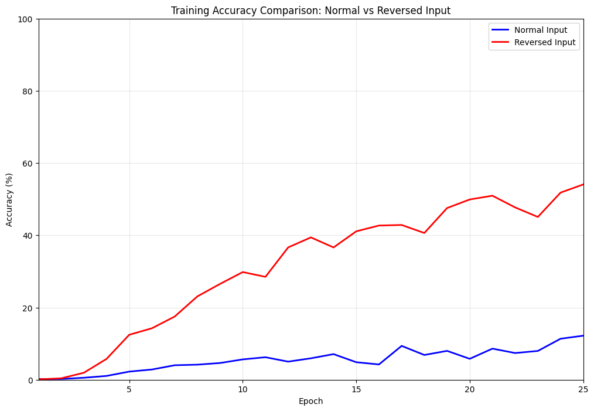

[output not shown]

```python
plt.figure(figsize=(12, 8))

plt.plot(range(1, len(acc_list) + 1), [acc * 100 for acc in acc_list],
         'b-', linewidth=2, label='Normal Input')
plt.plot(range(1, len(acc_list_reversed) + 1), [acc * 100 for acc in acc_list_reversed],
         'r-', linewidth=2, label='Reversed Input')

plt.xlabel('Epoch')
plt.ylabel('Accuracy (%)')
plt.title('Training Accuracy Comparison: Normal vs Reversed Input')
plt.legend()
plt.grid(True, alpha=0.3)
plt.xlim(1, max_epoch)
plt.ylim(0, 100)
plt.show()

print(f'Final accuracy (Normal): {acc_list[-1] * 100:.2f}%')
print(f'Final accuracy (Reversed): {acc_list_reversed[-1] * 100:.2f}%')
print(f'Improvement: {(acc_list_reversed[-1] - acc_list[-1]) * 100:.2f} percentage points')
```

### 7.4.2

엿보기(peeky seq2seq) 모델

[figure not shown]

seq2seq decoder 구조에서 저번에 봤듯이 최초 Affine/LSTM셀에게만 전달되는 이 'h' 정보를 모든 셀에 조금식 전달을 해주는 것이다. 전체 문맥을 모든 문장요소 구성에 전달하는 셈이 되는 것. 전체의 입력이 덧셈 결과(수 문자들)에 영향을 미치는거니 성능 개선에 큰 (좋은) 영향을 미칠 것이다.

[figure not shown]

셀에 'h' 정보 전달할 때는 concat (이어붙이기)로 전달을 해줌.

encoder는 똑같고 decoder만 이 변경사항을 적용하면 됨.

```python
from common.peeky_seq2seq import PeekySeq2seq

(x_train_rev, t_train_rev), (x_test_rev, t_test_rev) = sequence.load_data('addition.txt')

x_train_rev = x_train_rev[:, ::-1]
x_test_rev = x_test_rev[:, ::-1]

model_peeky = PeekySeq2seq(vocab_size, wordvec_size, hidden_size)
optimizer_peeky = Adam()
trainer_peeky = Trainer(model_peeky, optimizer_peeky)

acc_list_peeky = []

print("Training with PEEKY inputs...")
for epoch in range(max_epoch):
    trainer_peeky.fit(
        x_train_rev, t_train_rev,
        max_epoch=1,
        batch_size=batch_size,
        max_grad=max_grad
    )

    correct_num = 0
    for i in range(len(x_test_rev)):
        question, correct = x_test_rev[i], t_test_rev[i]
        verbose = False

        question = question.reshape(1, -1)
        correct = correct.reshape(1, -1)
        correct_num += eval_seq2seq(
            model_peeky, question, correct,
            id_to_char, verbose, is_reverse=True
        )

    acc = float(correct_num) / len(x_test_rev)
    acc_list_peeky.append(acc)
    print('검증 정확도: %.3f%%' % (acc * 100), end=' | ')
    print(f'Epoch {epoch + 1}')
```

```
Training with PEEKY inputs...
검증 정확도: 0.280% | Epoch 1
검증 정확도: 0.400% | Epoch 2
검증 정확도: 1.600% | Epoch 3
검증 정확도: 5.140% | Epoch 4
검증 정확도: 9.380% | Epoch 5
검증 정확도: 15.040% | Epoch 6
검증 정확도: 39.100% | Epoch 7
검증 정확도: 65.060% | Epoch 8
검증 정확도: 83.280% | Epoch 9
검증 정확도: 88.380% | Epoch 10
검증 정확도: 90.940% | Epoch 11
검증 정확도: 92.240% | Epoch 12
검증 정확도: 94.380% | Epoch 13
검증 정확도: 95.800% | Epoch 14
검증 정확도: 93.940% | Epoch 15
검증 정확도: 96.180% | Epoch 16
검증 정확도: 93.760% | Epoch 17
검증 정확도: 95.080% | Epoch 18
검증 정확도: 97.200% | Epoch 19
검증 정확도: 95.920% | Epoch 20
검증 정확도: 98.200% | Epoch 21
검증 정확도: 98.260% | Epoch 22
검증 정확도: 97.080% | Epoch 23
검증 정확도: 98.640% | Epoch 24
검증 정확도: 99.480% | Epoch 25
```

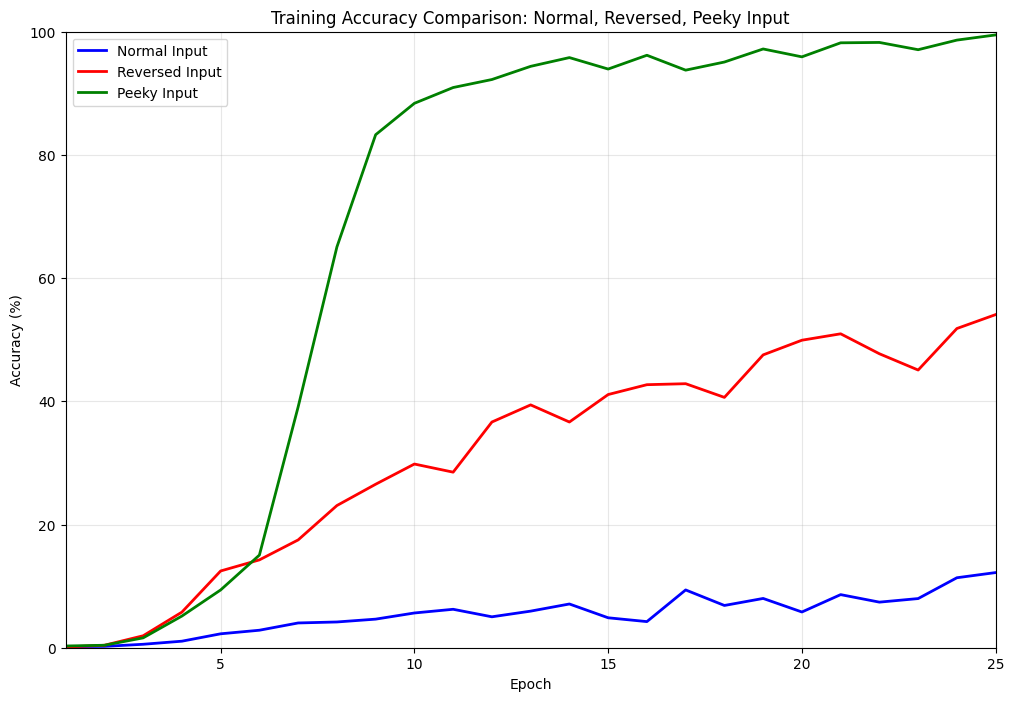

[output not shown]

```python
plt.figure(figsize=(12, 8))

plt.plot(range(1, len(acc_list) + 1), [acc * 100 for acc in acc_list],
         'b-', linewidth=2, label='Normal Input')
plt.plot(range(1, len(acc_list_reversed) + 1), [acc * 100 for acc in acc_list_reversed],
         'r-', linewidth=2, label='Reversed Input')
plt.plot(range(1, len(acc_list_peeky) + 1), [acc * 100 for acc in acc_list_peeky],
         'g-', linewidth=2, label='Peeky Input')

plt.xlabel('Epoch')
plt.ylabel('Accuracy (%)')
plt.title('Training Accuracy Comparison: Normal, Reversed, Peeky Input')
plt.legend()
plt.grid(True, alpha=0.3)
plt.xlim(1, max_epoch)
plt.ylim(0, 100)
plt.show()

print(f'Final accuracy (Normal): {acc_list[-1] * 100:.2f}%')
print(f'Final accuracy (Reversed): {acc_list_reversed[-1] * 100:.2f}%')
print(f'Final accuracy (Peeky): {acc_list_peeky[-1] * 100:.2f}%')
```

아주 결과가 잘나와요 👍

### 7.5

seq2seq를 사용하는 애플리케이션

- 기계 번역: ‘한 언어의 문장’을 ‘다른 언어의 문장’으로 변환
- 자동 요약: ‘긴 문장’을 ‘짧게 요약된 문장’으로 변환
- 질의응답: ‘질문’을 ‘응답’으로 변환
- 메일 자동 응답: ‘받은 메일의 문장’을 ‘답변 글’로 변환

대표적으로는 챗봇에도 쓰이고 (사용자 input -> 모델 output)

그리고 앞서 만들었던 덧셈 모델을 더 발전시키면 코드를 입력으로 그 코드가 만들어낼 output을 예상하는 모델도 만들 수 있다. -

[figure not shown]

코드든 자연어든 모두 다 시계열 데이터로 볼 수 있으므로 가능한데 그래서 위의 예시에 보여진 코드도 간단한거는 잘 할 수 있는데 for/while등의 loop가 들어가면 어려워할 수도 있음 (순차적이지 않고 일부 반복되는 부분이 있으므로)

물론 더 발전하고 메모리 등을 추가하면 다 해결은 될 문제들임.

글이나 텍스트 뿐만 아니라 음성/영상의 captioning에도 쓰일 수가 있다.

[figure not shown]

음성은 생각해보면 일련의 linear한 시계열 값이니 구현하기 쉽고, 영상의 경우는 위처럼 encoder부분만 CNN으로 대체한 것이다. decoder부분은 뭐 거의 그대로 사용해도 된다 하고 CNN같은 경우는 시계열 형태의 1차원 데이터로 flattening하는 작업만 거쳐서 입력으로 넣어주면 된느 것이다. 보통 이 경우에는 CNN모델은 VGG나 ResNet을 사용하고 흔히 쓰는 ImageNet등으로 pretrain을 거친 모델을 사용한다.

다음은 이 방식을 사용한 모델의 예시다.

[figure not shown]

ㅣ 정리 ㅣ

- RNN을 이용한 언어 모델은 새로운 문장을 생성할 수 있다.
- 문장을 생성할 때는 하나의 단어(혹은 문자)를 주고 모델의 출력(확률 분포)에서 샘플링하는 과정을 반복한다.
- RNN을 2개 조합하여 시계열 데이터를 다른 시계열 데이터로 변환할 수 있다.
- seq2seq는 Encoder가 출발어 입력문을 인코딩하고 Decoder가 인코딩된 정보를 받아 디코딩하여 도착어 출력문을 얻는다.
- 입력문을 반전시키는 기법(Reverse) 또는 인코딩된 정보를 Decoder의 여러 계층에 전달하는 기법(Peeky)은 seq2seq 정확도 향상에 효과적이다.
- 기계 번역, 챗봇, 이미지 캡셔닝 등 다양한 애플리케이션에 seq2seq를 이용할 수 있다.